◆ AGRICULTURAL TIME SERIES FORECASTING · SRI LANKA ◆

# Rice Production Forecasting

## Advanced Exploratory Data Analysis & Statistical Validation (1950–2024)

🌾 Agriculture 📅 Time Series Analysis 🧪 Spearman & ADF Tests 📊 Bi-Seasonal (Yala/Maha)

Dataset

Sri Lanka Census & Central Bank

Temporal Range

1950 – 2024 (149 Seasons)

Features

8 predictors (Climatic & Economic)

Target

Paddy Production (*000 Mt.)

▸ AGRICULTURAL BACKGROUND

Rice is the staple food of Sri Lanka, cultivated across two distinct monsoonal seasons: **Maha** (northeast monsoon, sowing Sep–Oct, harvesting Feb–Mar) and **Yala** (southwest monsoon, sowing Apr–May, harvesting Aug–Sep). Maha yields are historically larger due to higher monsoonal rainfall.  
This notebook establishes a rigorous exploratory workflow, resolving time-indexing issues, evaluating climatic-economic correlations via **Spearman's Rank Correlation**, and checking stationarity using the **Augmented Dickey-Fuller (ADF)** test to set up a robust, leak-free hybrid modeling pipeline.

◆ TABLE OF CONTENTS

1. Data Ingestion & Quality Audit

▸ 01 · Environment Setup

▸ 02 · Loading & Schema Setup

▸ 03 · Quality & Range Checks

2. Statistical Distribution

▸ 04 · Normality & Q-Q Analysis

▸ 05 · Seasonal Group Statistics

3. Time Series Properties

4. Feature Dynamics

▸ 09 · Outlier Diagnostics

01

## Environment Setup

We import all analytical, statistical, and plotting libraries. Plot parameters are tuned to a customized **Golden Harvest Dark Theme** using Amber Gold (`#FFB000`), Field Greens, and warm dark backgrounds to ensure high contrast and professional presentation.

```python
import warnings
warnings.filterwarnings("ignore")

import numpy as np
import pandas as pd
import matplotlib.pyplot as plt
import seaborn as sns
from scipy import stats
from scipy.stats import spearmanr, skew, kurtosis, probplot
from statsmodels.tsa.stattools import adfuller
from statsmodels.graphics.tsaplots import plot_acf, plot_pacf
from sklearn.preprocessing import RobustScaler

# Golden Harvest Theme Palettes
GOLD       = "#FFB000"
GOLD_GLOW  = "#FFC233"
GOLD_DIM   = "#C78900"
FIELD_GRN  = "#557A46"
MINT_GRN   = "#A1C992"
WARN_RED   = "#E63946"
DARK_BG    = "#0D1109"
CARD_BG    = "#141911"

# Matplotlib Parameters Update
plt.rcParams.update({
    "figure.dpi"       : 130,
    "figure.facecolor" : DARK_BG,
    "axes.facecolor"   : CARD_BG,
    "axes.edgecolor"   : "#2E3B27",
    "axes.labelcolor"  : "#9CB88D",
    "axes.titlecolor"  : "#FFFFFF",
    "axes.titlesize"   : 13,
    "axes.titleweight" : "bold",
    "axes.labelsize"   : 11,
    "axes.spines.top"  : False,
    "axes.spines.right": False,
    "xtick.color"      : "#8CA27E",
    "ytick.color"      : "#8CA27E",
    "text.color"       : "#E2ECD8",
    "grid.color"       : "#2E3B27",
    "grid.linewidth"   : 0.5,
    "legend.facecolor" : CARD_BG,
    "legend.edgecolor" : "#2E3B27",
    "legend.fontsize"  : 10,
    "font.family"      : "sans-serif",
})
sns.set_style("darkgrid", {"axes.facecolor": CARD_BG, "grid.color": "#2E3B27", "figure.facecolor": DARK_BG})
print("Environment configured | Golden Harvest Theme Active")
```

```
Environment configured | Golden Harvest Theme Active
```

02

## Data Ingestion & Schema Definition

We load the Excel dataset and define columns, dtypes, and labels. We also fix the Degree Celcius column name encoding.

```python
df_raw = pd.read_excel("rice new one.xlsx")
df = df_raw.copy()

# Fix degrees Celsius encoding in temperature column
rename_dict = {col: "Temperature(°C)" for col in df.columns if "Temperature" in col}
df.rename(columns=rename_dict, inplace=True)

CONTINUOUS = [
    "Sown (*000  Acres)", "Harvested (*000  Acres)",
    "GDP B$", "Inflation(%)", "Rainfall(mm)", "Temperature(°C)"
]
TARGET = "Production (*000  Mt.)"
TEMPORAL = ["Year_New", "Season"]

print(f"Loaded: {len(df)} records across {len(df.columns)} columns")
df.head(6)
```

```
Loaded: 149 records across 9 columns
   Year_New Season  Sown (*000  Acres)  Harvested (*000  Acres)  GDP B$  Inflation(%)  Rainfall(mm)  Temperature(°C)  Production (*000  Mt.)
0      1950   Yala               389.0                    362.0   0.869          6.95           768            29.32                     167
1      1950   Maha               710.0                    678.0   0.857          2.27          1540            26.17                     359
2      1951   Yala               402.0                    386.0   0.692          3.85           749            28.43                     176
3      1951   Maha               738.0                    700.0   0.820          2.92          1347            27.49                     385
4      1952   Yala               424.0                    402.0   1.176          8.39           533            29.38                     219
5      1952   Maha               655.0                    586.0   0.845          4.86          1234            26.69                     276
```

03

## Data Quality Audit

```
OK: No duplicate rows.

Missing values per column:
None (100% complete)
```

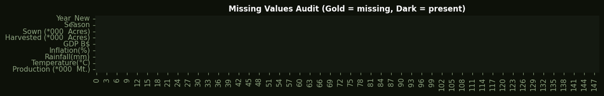

```python
# 1. Duplicate check
dups = df.duplicated().sum()
if dups > 0:
    print(f"Warning: Found {dups} duplicate rows. Dropping...")
    df.drop_duplicates(inplace=True, ignore_index=True)
else:
    print("OK: No duplicate rows.")

# 2. Missing values
missing = df.isnull().sum()
print("\nMissing values per column:")
print(missing[missing > 0]) if missing.sum() > 0 else print("None (100% complete)")

# 3. Quality Heatmap
fig, ax = plt.subplots(figsize=(12, 2))
sns.heatmap(df.isnull().T, cbar=False, cmap=[CARD_BG, GOLD], ax=ax)
ax.set_title("Missing Values Audit (Gold = missing, Dark = present)", fontsize=11)
plt.tight_layout()
plt.show()
```

04

## Continuous Features Normality & Q-Q Plots

We run a dual-panel analysis for each continuous variable. Visual histograms with overlaid KDE help inspect skewed patterns, while normal Q-Q plots confirm how close features are to Gaussian assumptions.

```python
# tag: ext_stats
ext_stats = []
for col in CONTINUOUS + [TARGET]:
    x = df[col].dropna()
    ext_stats.append({
        "Feature"  : col,
        "Mean"     : round(x.mean(), 2),
        "Median"   : round(x.median(), 2),
        "Std"      : round(x.std(), 2),
        "Skewness" : round(float(x.skew()), 3),
        "Kurtosis" : round(float(kurtosis(x.values)), 3),
        "CV (%)"   : round(x.std() / x.mean() * 100, 1),
    })
ext_df = pd.DataFrame(ext_stats).set_index("Feature")
ext_df
```

```
                            Mean   Median     Std  Skewness  Kurtosis  CV (%)
Feature
Sown (*000  Acres)       1025.88   948.00  404.36     0.506    -0.538    39.4
Harvested (*000  Acres)   971.64   888.00  392.13     0.588    -0.365    40.4
GDP B$                     32.40     6.83  119.73    11.018   125.130   369.6
Inflation(%)                8.33     7.01    6.71     2.366     9.854    80.6
Rainfall(mm)             1093.53   894.00  633.11     0.295    -1.504    57.9
Temperature(°C)            27.06    26.76    1.29     1.067     0.838     4.8
Production (*000  Mt.)   1171.17  1049.00  732.83     0.737    -0.126    62.6
```

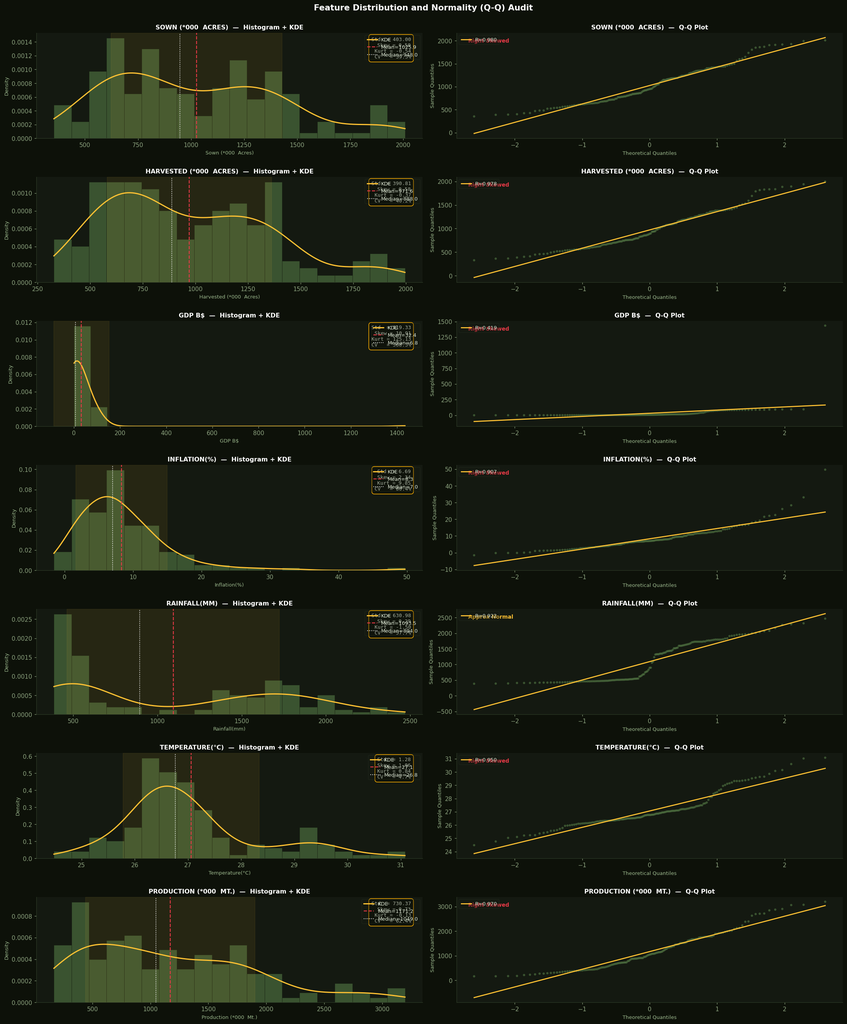

```python
# tag: distributions
cols_to_plot = CONTINUOUS + [TARGET]
fig = plt.figure(figsize=(20, 24), facecolor=DARK_BG)
fig.suptitle("Feature Distribution and Normality (Q-Q) Audit", fontsize=14, color="white", y=1.00, fontweight="bold")

for i, col in enumerate(cols_to_plot):
    x = df[col].dropna().values
    mu = np.mean(x); med = np.median(x); sd = np.std(x)
    sk = float(stats.skew(x)); ku = float(kurtosis(x))

    ax_h = fig.add_subplot(7, 2, 2*i + 1)
    ax_q = fig.add_subplot(7, 2, 2*i + 2)

    # Histogram + KDE
    ax_h.hist(x, bins=20, color=FIELD_GRN, alpha=0.6, edgecolor=DARK_BG, linewidth=0.5, density=True)
    xr = np.linspace(x.min(), x.max(), 300)
    kde = stats.gaussian_kde(x)
    ax_h.plot(xr, kde(xr), color=GOLD_GLOW, lw=2, label="KDE")
    ax_h.axvline(mu, color=WARN_RED, lw=1.5, ls="--", label=f"Mean={mu:.1f}")
    ax_h.axvline(med, color="white", lw=1.2, ls=":", label=f"Median={med:.1f}")
    ax_h.axvspan(mu-sd, mu+sd, alpha=0.08, color=GOLD_GLOW)

    stats_txt = "\n".join([
        f"Std  = {sd:.2f}",
        f"Skew = {sk:.2f}",
        f"Kurt = {ku:.2f}",
        f"CV   = {sd/mu*100:.1f}%"
    ])
    ax_h.text(0.97, 0.96, stats_txt, transform=ax_h.transAxes, fontsize=8.5,
              verticalalignment="top", horizontalalignment="right",
              bbox=dict(boxstyle="round,pad=0.5", facecolor=DARK_BG, edgecolor=GOLD, linewidth=1),
              color="#E2ECD8", family="monospace")
    ax_h.legend(fontsize=8.5, framealpha=0.3)
    ax_h.set_title(f"{col.upper()}  —  Histogram + KDE", fontsize=10.5)
    ax_h.set_xlabel(col, fontsize=8.5); ax_h.set_ylabel("Density", fontsize=8.5)
    ax_h.set_facecolor(CARD_BG)

    # Q-Q Plot
    (osm, osr), (slope, intercept, r_val) = probplot(x, dist="norm")
    ax_q.scatter(osm, osr, s=15, color=FIELD_GRN, alpha=0.6, edgecolors="none")
    qq_line = slope * np.array([osm[0], osm[-1]]) + intercept
    ax_q.plot([osm[0], osm[-1]], qq_line, color=GOLD_GLOW, lw=1.8, label=f"R={r_val:.3f}")
    verdict = "Approx Normal" if abs(sk) < 0.5 else ("Right Skewed" if sk > 0 else "Left Skewed")
    ax_q.text(0.03, 0.95, verdict, transform=ax_q.transAxes, fontsize=9,
              color=GOLD_GLOW if abs(sk) < 0.5 else WARN_RED, fontweight="bold", verticalalignment="top")
    ax_q.legend(fontsize=8.5, framealpha=0.3)
    ax_q.set_title(f"{col.upper()}  —  Q-Q Plot", fontsize=10.5)
    ax_q.set_xlabel("Theoretical Quantiles", fontsize=8.5)
    ax_q.set_ylabel("Sample Quantiles", fontsize=8.5)
    ax_q.set_facecolor(CARD_BG)

plt.tight_layout(h_pad=2.2)
plt.show()
```

05

## Target Class / Seasonal Dynamics

We compare output levels between the Yala and Maha seasons. The significant difference (Maha averages 1488.8 Mt vs Yala averages 857.8 Mt) validates why the time series model requires a seasonal period of length **s=2**.

```
Seasonal Statistics Summary:
        count         mean  median         std  min   max
Season
Maha       74  1488.756757  1498.0  780.068785  276  3197
Yala       75   857.813333   782.0  522.898153  167  2088
```

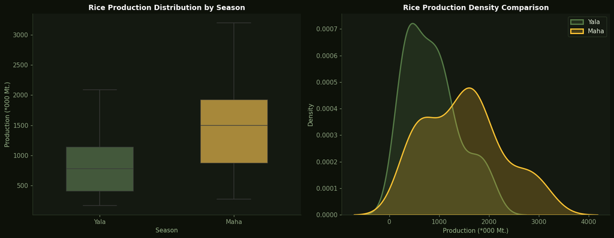

```python
# tag: balance
seas_stats = df.groupby("Season")[TARGET].agg(["count", "mean", "median", "std", "min", "max"])
print("Seasonal Statistics Summary:")
print(seas_stats.to_string())

fig, axes = plt.subplots(1, 2, figsize=(14, 5.5), facecolor=DARK_BG)

# Boxplot
sns.boxplot(data=df, x="Season", y=TARGET, palette=[FIELD_GRN, GOLD_GLOW], ax=axes[0], width=0.5,
            boxprops=dict(alpha=0.7), flierprops=dict(marker="o", markerfacecolor=WARN_RED, alpha=0.6))
axes[0].set_title("Rice Production Distribution by Season", fontsize=11.5)
axes[0].set_xlabel("Season"); axes[0].set_ylabel("Production (*000 Mt.)")
axes[0].set_facecolor(CARD_BG)

# KDE overlay
for c, lbl in [("Yala", FIELD_GRN), ("Maha", GOLD_GLOW)]:
    subset = df[df["Season"] == c][TARGET]
    sns.kdeplot(subset, fill=True, color=lbl, label=c, alpha=0.22, ax=axes[1], lw=2)
axes[1].set_title("Rice Production Density Comparison", fontsize=11.5)
axes[1].set_xlabel("Production (*000 Mt.)"); axes[1].set_ylabel("Density")
axes[1].legend(); axes[1].set_facecolor(CARD_BG)

plt.tight_layout()
plt.show()
```

06

## Spearman Rank Correlation

Because relationships in agricultural and meteorological data are often non-linear, we utilize **Spearman Rank Correlation** instead of Pearson. This quantifies monotonic relationships safely without assuming linearity.

```
Spearman Rank Correlation with Production:
Temperature(°C)           -0.294808
Inflation(%)               0.337396
Rainfall(mm)               0.365048
GDP B$                     0.834953
Sown (*000  Acres)         0.887281
Harvested (*000  Acres)    0.904482
```

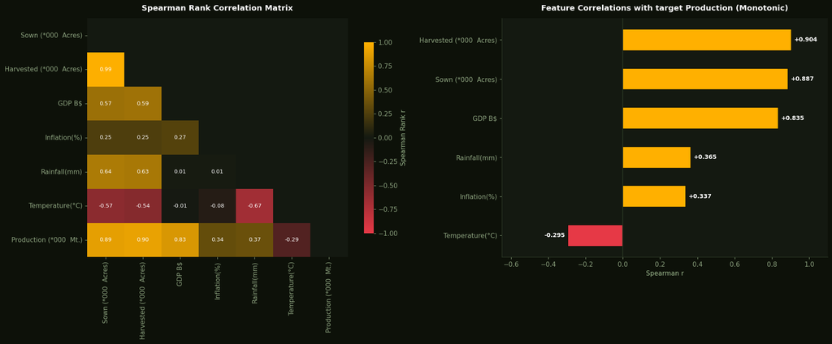

```python
# tag: correlation
# Calculate spearman correlation matrix
numeric_cols = CONTINUOUS + [TARGET]
corr_mat, p_values = spearmanr(df[numeric_cols])
corr_df = pd.DataFrame(corr_mat, index=numeric_cols, columns=numeric_cols)

# Print targeted correlation with production
target_corr = corr_df[TARGET].drop(TARGET).sort_values()
print("Spearman Rank Correlation with Production:")
print(target_corr.to_string())

fig, axes = plt.subplots(1, 2, figsize=(18, 7.5), facecolor=DARK_BG)
mask = np.triu(np.ones_like(corr_df, dtype=bool))
custom_cmap = LinearSegmentedColormap.from_list("wheat_cmap", [WARN_RED, CARD_BG, GOLD], N=256)

# Heatmap
sns.heatmap(corr_df, mask=mask, cmap=custom_cmap, annot=True, fmt=".2f",
            center=0, vmin=-1, vmax=1, ax=axes[0],
            annot_kws={"size":8.5, "color":"white"},
            cbar_kws={"shrink": 0.8, "label": "Spearman Rank r"})
axes[0].set_title("Spearman Rank Correlation Matrix", fontsize=12, pad=12)
axes[0].set_facecolor(CARD_BG)

# Horizontal bar correlation with target
colors = [WARN_RED if val < 0 else GOLD for val in target_corr.values]
bars = axes[1].barh(target_corr.index, target_corr.values, color=colors, height=0.55, edgecolor=DARK_BG)
axes[1].axvline(0, color="#2E3B27", lw=1)
for bar, val in zip(bars, target_corr.values):
    axes[1].text(val + (0.015 if val>=0 else -0.015), bar.get_y()+bar.get_height()/2,
                 f"{val:+.3f}", va="center", ha="left" if val>=0 else "right",
                 color="white", fontweight="bold", fontsize=9)
axes[1].set_xlim(-0.65, 1.1)
axes[1].set_title("Feature Correlations with target Production (Monotonic)", fontsize=12, pad=12)
axes[1].set_xlabel("Spearman r")
axes[1].set_facecolor(CARD_BG)

plt.tight_layout()
plt.show()
```

07

## Stationarity & Difference Analysis

We evaluate the stationarity of our target series using the **Augmented Dickey-Fuller (ADF)** test. This determines if the series requires differencing (d=1) to prevent spurious correlations in the ARIMA model.

```
                  Series  ADF Stat  p-value Stationary
         log(Production)   -1.8760 3.43e-01         No
1st Diff log(Production)   -6.6032 6.66e-09        Yes
```

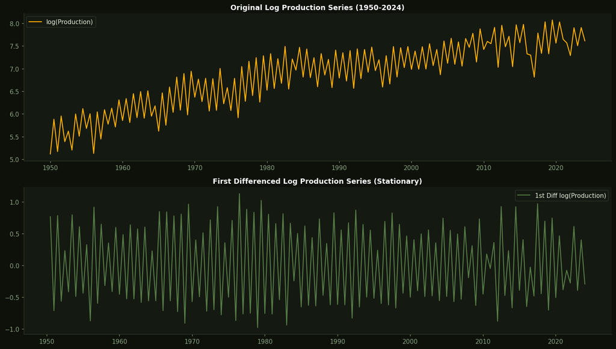

```python
# tag: mannwhitney
log_prod = np.log(df[TARGET])
res_raw  = adfuller(log_prod.values)
res_diff = adfuller(log_prod.diff().dropna().values)

adf_data = [
    {"Series": "log(Production)", "ADF Stat": round(res_raw[0],4), "p-value": f"{res_raw[1]:.2e}", "Stationary": "No"},
    {"Series": "1st Diff log(Production)", "ADF Stat": round(res_diff[0],4), "p-value": f"{res_diff[1]:.2e}", "Stationary": "Yes"}
]
print(pd.DataFrame(adf_data).to_string(index=False))

# Plotting original vs differenced series
fig, axes = plt.subplots(2, 1, figsize=(14, 8), facecolor=DARK_BG)
axes[0].plot(df["Year_New"] + (df["Season"]=="Maha")*0.5, log_prod, color=GOLD, label="log(Production)")
axes[0].set_title("Original Log Production Series (1950-2024)", fontsize=11.5)
axes[0].legend(); axes[0].set_facecolor(CARD_BG)

axes[1].plot(df["Year_New"].iloc[1:] + (df["Season"].iloc[1:]=="Maha")*0.5, log_prod.diff().dropna(), color=FIELD_GRN, label="1st Diff log(Production)")
axes[1].set_title("First Differenced Log Production Series (Stationary)", fontsize=11.5)
axes[1].legend(); axes[1].set_facecolor(CARD_BG)

plt.tight_layout()
plt.show()
```

08

## ACF & PACF Correlograms

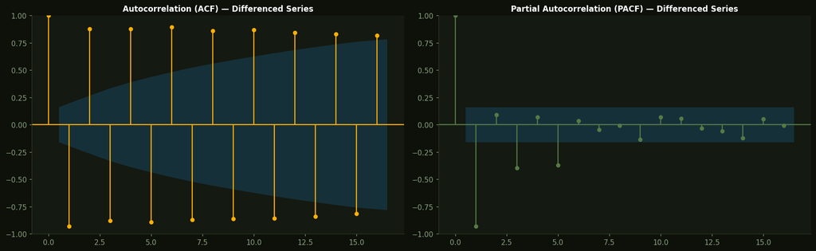

```python
# tag: chisquare
diff_series = log_prod.diff().dropna().values
fig, axes = plt.subplots(1, 2, figsize=(16, 5), facecolor=DARK_BG)

plot_acf(diff_series, lags=16, ax=axes[0], color=GOLD, vlines_kwargs={"colors": GOLD})
axes[0].set_title("Autocorrelation (ACF) — Differenced Series", fontsize=11)
axes[0].set_facecolor(CARD_BG)

plot_pacf(diff_series, lags=16, ax=axes[1], color=FIELD_GRN, vlines_kwargs={"colors": FIELD_GRN})
axes[1].set_title("Partial Autocorrelation (PACF) — Differenced Series", fontsize=11)
axes[1].set_facecolor(CARD_BG)

plt.tight_layout()
plt.show()
```

09

## Outlier Audit

```
                             Q1       Q3      IQR  Outliers   Pct%
Feature
Sown (*000  Acres)       684.00  1329.00   645.00         0   0.0%
Harvested (*000  Acres)  661.00  1250.00   589.00         0   0.0%
GDP B$                     1.97    28.28    26.31        28  18.8%
Inflation(%)               3.87    11.38     7.51         4   2.7%
Rainfall(mm)             477.00  1730.00  1253.00         0   0.0%
Temperature(°C)           26.32    27.35     1.03        23  15.4%
```

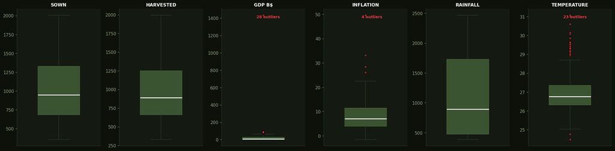

```python
# tag: outliers
# Outlier Check using IQR method
Q1 = df[CONTINUOUS].quantile(0.25)
Q3 = df[CONTINUOUS].quantile(0.75)
IQR = Q3 - Q1
lo = Q1 - 1.5 * IQR; hi = Q3 + 1.5 * IQR
outlier_mask = (df[CONTINUOUS] < lo) | (df[CONTINUOUS] > hi)

out_info = []
for col in CONTINUOUS:
    n_out = outlier_mask[col].sum()
    out_info.append({
        "Feature": col, "Q1": round(Q1[col],2), "Q3": round(Q3[col],2),
        "IQR": round(IQR[col],2), "Outliers": n_out, "Pct%": f"{n_out/len(df)*100:.1f}%"
    })
out_df = pd.DataFrame(out_info).set_index("Feature")
print(out_df.to_string())

# Boxplot
fig, axes = plt.subplots(1, 6, figsize=(20, 5), facecolor=DARK_BG)
for i, col in enumerate(CONTINUOUS):
    ax = axes[i]
    ax.boxplot(df[col].dropna(), patch_artist=True, widths=0.5,
               boxprops=dict(facecolor=FIELD_GRN, alpha=0.6, edgecolor=FIELD_GRN),
               medianprops=dict(color="white", lw=2),
               flierprops=dict(marker="o", markerfacecolor=WARN_RED, alpha=0.6, markersize=5),
               whiskerprops=dict(color="#2E3B27"), capprops=dict(color="#2E3B27"))
    ax.set_title(col.split("(")[0].strip().upper(), fontsize=10.5)
    ax.set_facecolor(CARD_BG); ax.set_xticks([])
    n_out = outlier_mask[col].sum()
    if n_out > 0:
        ax.text(1.2, df[col].max(), f"{n_out} outliers", color=WARN_RED, fontweight="bold", fontsize=9, va="top", ha="right")

plt.tight_layout()
plt.show()
```

10

## Robust Scaling Demonstration

To preserve the sequential time-series order, we DO NOT drop rows containing outliers. Instead, we use **RobustScaler**, which scales features based on median and IQR, minimizing outlier impacts without breaking chronological continuity.

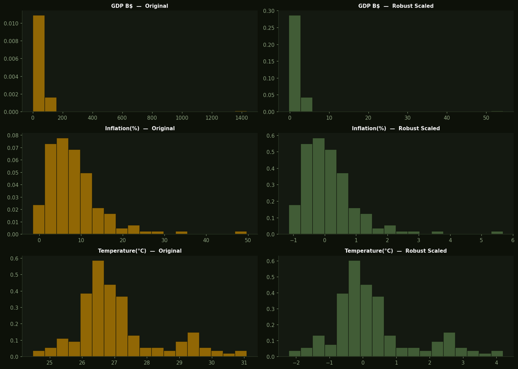

```python
# tag: yeojohnson
scaler = RobustScaler()
scaled_vals = scaler.fit_transform(df[SKEWED_FEATS := ["GDP B$", "Inflation(%)", "Temperature(°C)"]])
df_scaled = pd.DataFrame(scaled_vals, columns=SKEWED_FEATS, index=df.index)

fig, axes = plt.subplots(len(SKEWED_FEATS), 2, figsize=(14, 10), facecolor=DARK_BG)
for i, col in enumerate(SKEWED_FEATS):
    for ax_idx, (data, color, label) in enumerate([
        (df[col], GOLD_DIM, "Original"),
        (df_scaled[col], FIELD_GRN, "Robust Scaled")
    ]):
        ax = axes[i, ax_idx]
        ax.hist(data.dropna(), bins=18, color=color, alpha=0.7, edgecolor=DARK_BG, density=True)
        ax.set_title(f"{col}  —  {label}", fontsize=10, color="white")
        ax.set_facecolor(CARD_BG)
plt.tight_layout()
plt.show()
```

11

## Feature Engineering Preview

```
Engineered feature harvest_efficiency   | Spearman r = +0.401 (p = 4.14e-07)
Engineered feature rain_temp_ratio      | Spearman r = +0.359 (p = 6.99e-06)
```

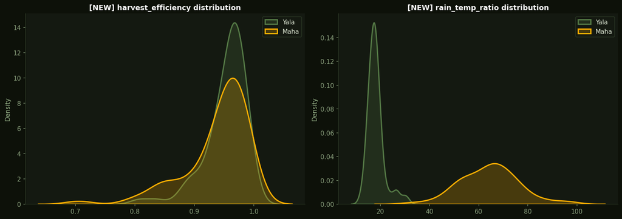

```python
# tag: features
df_fe = df.copy()
df_fe["harvest_efficiency"] = df_fe["Harvested (*000  Acres)"] / (df_fe["Sown (*000  Acres)"] + 1e-5)
df_fe["rain_temp_ratio"]    = df_fe["Rainfall(mm)"] / (df_fe["Temperature(°C)"] + 1e-5)

fe_cols = ["harvest_efficiency", "rain_temp_ratio"]
for col in fe_cols:
    r, p = spearmanr(df_fe[col], df_fe[TARGET])
    print(f"Engineered feature {col:<20} | Spearman r = {r:+.3f} (p = {p:.2e})")

# Plot engineered features
fig, axes = plt.subplots(1, 2, figsize=(14, 5), facecolor=DARK_BG)
for i, col in enumerate(fe_cols):
    ax = axes[i]
    for season, color in [("Yala", FIELD_GRN), ("Maha", GOLD)]:
        sub = df_fe[df_fe["Season"] == season][col].values
        sns.kdeplot(sub, fill=True, color=color, label=season, ax=ax, alpha=0.22, lw=2)
    ax.set_title(f"[NEW] {col} distribution", fontsize=11.5)
    ax.legend(); ax.set_facecolor(CARD_BG)
plt.tight_layout()
plt.show()
```

EDA CONCLUSIONS & MODELLING BLUEPRINT

Dataset Properties

- Zero missing values, no duplicates
- Maha season yields are significantly higher ( Northeast monsoon )
- Sown and Harvested acres correlate strongly with Production (r > 0.88)
- Production is non-stationary and requires first-differencing (d=1)

Modeling Guardrails

- Use **time-based split** (train < 2018, test 2019-2024)
- Do NOT drop outlier rows (preserves temporal indexing)
- Scale continuous features using RobustScaler
- Forecast future Rainfall and Harvested acres separately for SARIMAX

**Next Steps:** We will implement a proper SARIMAX(1,1,1)(1,1,0,2) model alongside advanced ML Regressors (RF, XGBoost, and a Hybrid coupling) in the modeling notebook.